# QTM 151 - Quiz 2

## Try to submit as an HTML file

Print your name below

```python
# Write your answer here

print("Parker Shimp")
```

```
Parker Shimp
```

This quiz is open book

- You can use the lecture notes
- You will get partial credit for attempting the questions
- To get full credit, the code should run as intended
- You should NOT communicate with other students

Print the following message:

"I will abide by Emory's code of conduct"

```python
# Write your answer here:

print("I will abide by Emory's code of conduct")
```

```
I will abide by Emory's code of conduct
```

Import the libraries "numpy", "matplotlib.pyplot", and "pandas"

```python
# Write your answer here
import numpy as np
import matplotlib.pyplot as plt
import pandas as pd
```

Import the dataset "data_quiz/fifa23_players_basic.csv"

- It's a dataset on professional soccer players
- Rows correspond to players (18,539)
- Columns contain attributes of players (32)
- Try to view the dataset before starting

```python
# Write your own code

fifa=pd.read_csv("fifa23_players_basic.csv")
```

(a) Create a function and apply it to a column

Step 1:

- Define a function with a parameter "age_player"
- If "age_player < 20", status = "Less than 20"
- If "age_player >= 20", status = "20 or older"
- The function returns "status"

Step 2:

- Extract the column "Age" in the dataset

(be carefeful to write the "A" capitalized)

- Create a new variable called "age_bracket"

to assign each player to the correct age bracket

HINT: Use the ".apply()" function

```python
# Write your own code

def check_age(age_player):
    if age_player<20:
        status="Less than 20"
    if age_player>=20:
        status="20 or older"
    return status

fifa["age_bracket"]=fifa["Age"].apply(check_age)
```

(b) Use queries + global variables

- Compute the mean of the column "Value(in Euro)"

and store it as a variable

- Subset the players whose value is above the mean value  
  using ".query()"

HINT: Remember that there is a special syntax for  
when the column names have spaces (see Lecture 10)  
Reference the column as `` `Value(in Euro)` `` inside .query()

```python
# Write your own code
mean_val = fifa["Value(in Euro)"].mean()
fifa_abv = fifa.query(" `Value(in Euro)` > @mean_val ")
```

(c) Use sorting + ".iloc[]"

- Use ".sort_values()" to order the "Age" column

from youngest to oldest

- Get a subset with the 5 youngest players

```python
# Write your own code

fifa_ascendingage = fifa.sort_values(by = "Age",ascending = True)
display(fifa_ascendingage.iloc[0:5,:])
```

|  | Known As | Full Name | Overall | Potential | Value(in Euro) | Positions Played | Best Position | Nationality | Image Link | Age | ... | Weak Foot Rating | Skill Moves | International Reputation | National Team Name | National Team Image Link | National Team Position | National Team Jersey Number | Attacking Work Rate | Defensive Work Rate | age_bracket |
| --- | --- | --- | --- | --- | --- | --- | --- | --- | --- | --- | --- | --- | --- | --- | --- | --- | --- | --- | --- | --- | --- |
| 17956 | A. Dithmer | Andreas Dithmer | 53 | 76 | 275000 | GK | GK | Denmark | https://cdn.sofifa.net/players/269/573/23_60.png | 16 | ... | 2 | 1 | 1 | - | https://cdn.sofifa.net/flags/dk.png | - | - | Medium | Medium | Less than 20 |
| 18014 | J. Ardila | José Ardila | 53 | 73 | 250000 | CM | CAM | Venezuela | https://cdn.sofifa.net/players/268/892/23_60.png | 16 | ... | 3 | 2 | 1 | - | https://cdn.sofifa.net/flags/ve.png | - | - | Medium | Medium | Less than 20 |
| 16084 | S. Ngoma | Serge Ngoma | 58 | 82 | 650000 | RW | RM | United States | https://cdn.sofifa.net/players/267/796/23_60.png | 16 | ... | 3 | 2 | 1 | - | https://cdn.sofifa.net/flags/us.png | - | - | High | Medium | Less than 20 |
| 11481 | O. Vargas | Obed Vargas | 64 | 81 | 1500000 | CM,CDM,RM | CAM | United States | https://cdn.sofifa.net/players/263/701/23_60.png | 16 | ... | 3 | 3 | 1 | - | https://cdn.sofifa.net/flags/us.png | - | - | High | Medium | Less than 20 |
| 17591 | A. Madaliński | Alan Madaliński | 54 | 68 | 210000 | GK | GK | Poland | https://cdn.sofifa.net/players/270/590/23_60.png | 16 | ... | 3 | 1 | 1 | - | https://cdn.sofifa.net/flags/pl.png | - | - | Medium | Medium | Less than 20 |

5 rows × 33 columns

(d) Create a function with four inputs $f(y,x,b0,b1)$

$\qquad e2 = (y - b_0 - b_1 * x)^2$

- The function should return the mean of e2
- This is the mean-square error (mse)
- Call the function "fn_mse"
- Let $y$ be the column "Potential"
- Let $x$ be the column "Age"
- Does

$\qquad (b_0 = 80, b_1 = -1)$ or  
$\qquad (b_0 = 80, b_1 =-0.4)$ or  
$\qquad (b_0 = 80, b_1 = 1)$  
produce the lowest value of mse?

```python
# Write your own code
e2_list=[]
def fn_mse(y,x,b0,b1):
    e2 = (y-b0-(b1*x))**2
    e2_list.append(e2)
    avg=np.mean(e2_list)
    return avg

display(fn_mse(fifa["Potential"],fifa["Age"],80,-1))
display(fn_mse(fifa["Potential"],fifa["Age"],80,0.4))
fn_mse(fifa["Potential"],fifa["Age"],80,1)
```

```
309.49360806947516
```

```
360.79764604347594
```

```
656.2925925526367
```

(e) Split a dataset into subsets

- Create `list_status = [0,1]`
- Create `list_prob = [0.5, 0.5]`
- Create a new variable $n$ with the number of rows of the dataset
- Use

```
np.random.choice(list_status,
                     size = n,
                     p = list_prob)
```

$\qquad$ to create a new column called "status"  
$\qquad$ which randomly assigns each row to "0" or "1"  
$\qquad$ with equal probability

- Use .query() to subset all observations with status == 0.

store it in a new dataset called "data0"

- Use .query() to subset all observations with status == 1.

store it in a new dataset called "data1"

```python
# Write your own code
list_status = [0,1]
list_prob = [0.5, 0.5]

n = len(fifa)
fifa["status"] = np.random.choice(list_status,
                     size = n,
                     p = list_prob)

data0 = fifa.query("status == 0")
data1 = fifa.query("status == 1")
```

(f) Create two overlapping histogram plots

- This function requires the two datasets you created in (e)
- Display the distribution of "Age" for "data0" and "data1"
- Use the "alpha" option to make the graphs semitransparent
- You will need to add a legend, label the axes, and the title

Note: The goal of this question is to illustrate that random  
assignment produces very similar distributions between two groups

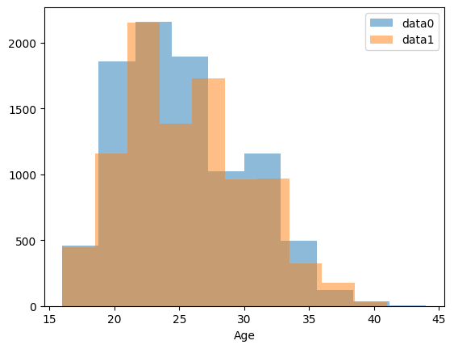

```python
# Write your own code
datasets = [data0, data1]
labels_list = ['data0', 'data1']
for dataset in datasets:
    plt.hist(dataset["Age"],alpha = 0.5)

plt.legend(labels = labels_list)
plt.xlabel("Age")
```